# Module 44

#### Hemi-module gene counts:

122 probesets in hemi-module A.  
79 probesets in hemi-module B.  
Note: While the mapping of probesets to genes is usually one-to-one, some genes are targeted by multiple probesets, some probesets target multiple genes, and some probesets do not target any genes (i.e., the region of the genome they match is no longer considered genic).

#### Contrast SVE:

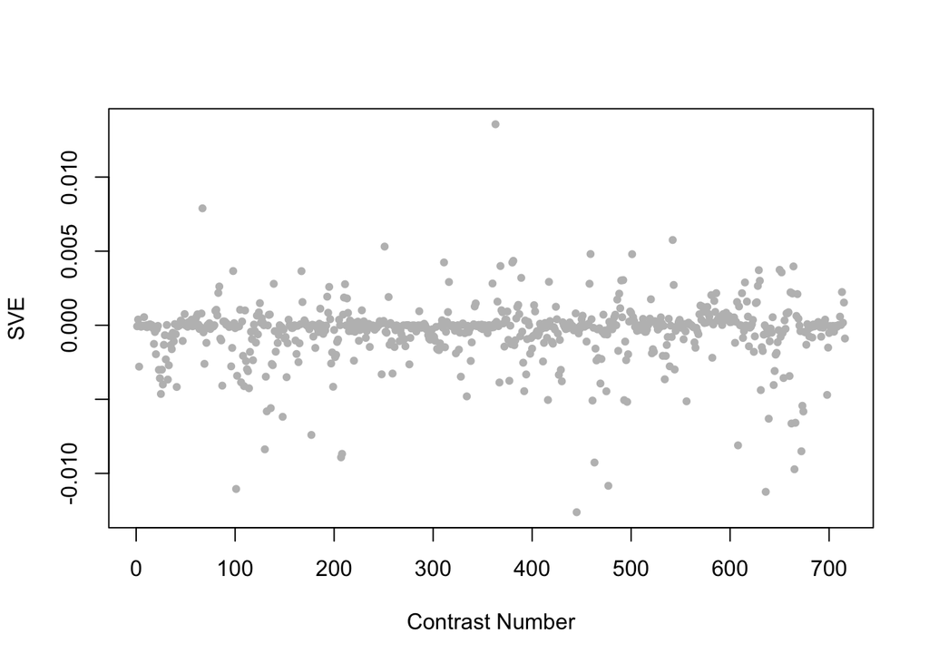

Positive SVE Contrasts:

|  | Contrast.Num | SVE | GEO.GSE | Cond.1 | Cond.2 | Mutation |
| --- | --- | --- | --- | --- | --- | --- |
| GSE36358.s2t1.vs.s0t1 | 363 | 0.01 | GSE36358 | Clino Rotation | Ground Control (Tsukuba space center) |  |
| GSE8659.s3t1.vs.s2t1 | 67 | 0.01 | GSE8659 | strain NL 2099 replicate 2 | strain GR1373 replicate 1 |  |
| GSE2180.s3t2.vs.s2t2 | 542 | 0.01 | GSE2180 | p23-2 | ms23-1 |  |
| GSE42192.s2t1.vs.s0t1 | 251 | 0.01 | GSE42192 | C.elegans fed with CNCM I-4317 3 days rep1 | C.elegans fed with E.coli OP50 3 days rep1 |  |
| GSE23843B.s1t1.vs.s0t1 | 459 | 0.00 | GSE23843 | RNP-8 rnp-8(q784)-IP, biological replicate 1 | RNP-8 wt-IP, biological replicate 1 |  |

Negative SVE Contrasts:

|  | Contrast.Num | SVE | GEO.GSE | Cond.1 | Cond.2 | Mutation |
| --- | --- | --- | --- | --- | --- | --- |
| GSE27677B.s0t9.vs.s0t7 | 445 | -0.01 | GSE27677 | N2, Fed 48 h, rep 1 | N2, Fed 24 h, rep 1 |  |
| GSE18132.s2t2.vs.s0t2 | 636 | -0.01 | GSE18132 | Oga Fed L4, biological replicate 1 | WT Fed L4, biological rep1 | oga-1 |
| GSE5793.s1t2.vs.s1t1 | 101 | -0.01 | GSE5793 | Celegans_gacA_8hours_RepA | Celegans_gacA_4hours_RepA |  |
| GSE23528A.s1t2.vs.s1t1 | 477 | -0.01 | GSE23528 | Adult at T6 in LD, time-series experiment 3 | Adult at T2 in LD, time-series experiment 3 |  |
| GSE15159.s1t2.vs.s1t1 | 665 | -0.01 | GSE15159 | glp-1_UV_2007_rep1 | glp-1_control_2007_rep1 |  |

$~$

#### Contrast SVE, Up-Regulated Genes Only:

Calculating SVE for up-regulated and down-regulated genes separately may be more informative in many cases than projecting the up- and down- gene sets together. This is due to the fact that the weight distribution of many modules is highly skewed, indicating that only one of the hemi-modules may be biologically meaningful (i.e., a set of genes are strongly correlated by only a few genes (or none) are strongly anti-correlated to that set.)

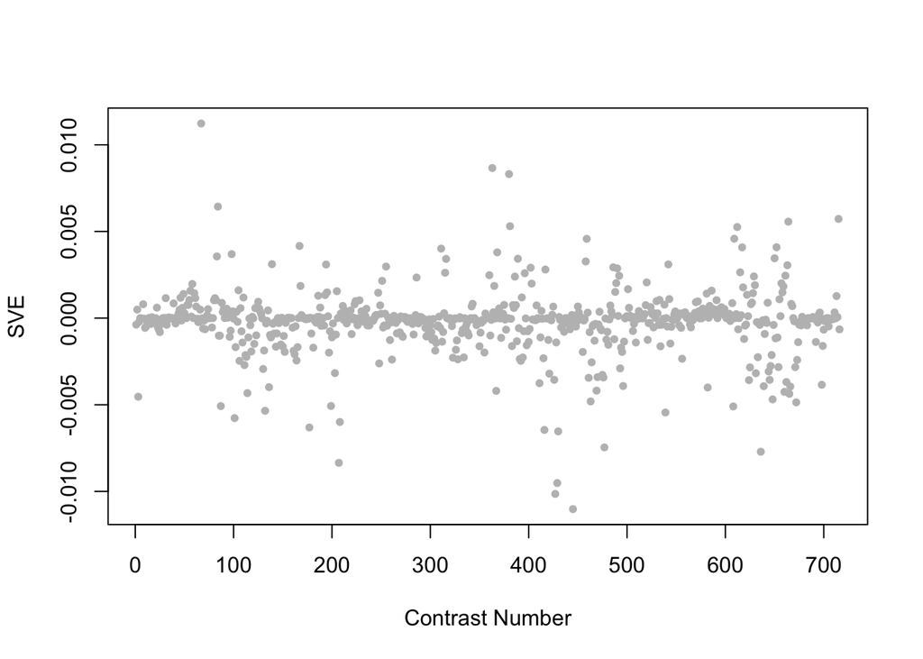

Positive SVE Contrasts:

|  | Contrast.Num | SVE | GEO.GSE | Cond.1 | Cond.2 | Mutation |
| --- | --- | --- | --- | --- | --- | --- |
| GSE8659.s3t1.vs.s2t1 | 67 | 0.01 | GSE8659 | strain NL 2099 replicate 2 | strain GR1373 replicate 1 |  |
| GSE36358.s2t1.vs.s0t1 | 363 | 0.01 | GSE36358 | Clino Rotation | Ground Control (Tsukuba space center) |  |
| GSE34471.s1t1.vs.s0t1 | 380 | 0.01 | GSE34471 | 4uM-Exp1 | 4uM-Con-1 | hrg-2 |
| GSE6547.s2t2.vs.s0t2 | 84 | 0.01 | GSE6547 | slr-2(ku297) worms at L1 stage, first replicate | N2 (wt) worms at L1 stage, first replicate | sir-2 |
| GSE10787A.s1t1.vs.s0t1 | 715 | 0.01 | GSE10787 | Depomerai_heat_shock_1 | Depomerai_heat_control_1 |  |

Negative SVE Contrasts:

|  | Contrast.Num | SVE | GEO.GSE | Cond.1 | Cond.2 | Mutation |
| --- | --- | --- | --- | --- | --- | --- |
| GSE27677B.s0t9.vs.s0t7 | 445 | -0.01 | GSE27677 | N2, Fed 48 h, rep 1 | N2, Fed 24 h, rep 1 |  |
| GSE27677A.s1t2.vs.s0t2 | 427 | -0.01 | GSE27677 | kgb-1, Fast , rep 1 | N2, Fast , rep 1 | kgb-1 |
| GSE27677A.s2t1.vs.s0t1 | 429 | -0.01 | GSE27677 | jun-1, Fed , rep 1 | N2, Fed , rep 1 | 40694 |
| GSE42703.s1t2.vs.s1t1 | 207 | -0.01 | GSE42703 | kgb-1 incubated with H2O, biological rep1 | kgb-1 incubated with 1mM copper sulfate, biological rep1 |  |
| GSE18132.s2t2.vs.s0t2 | 636 | -0.01 | GSE18132 | Oga Fed L4, biological replicate 1 | WT Fed L4, biological rep1 | oga-1 |

$~$

#### Contrast SVE, Down-Regulated Genes Only:

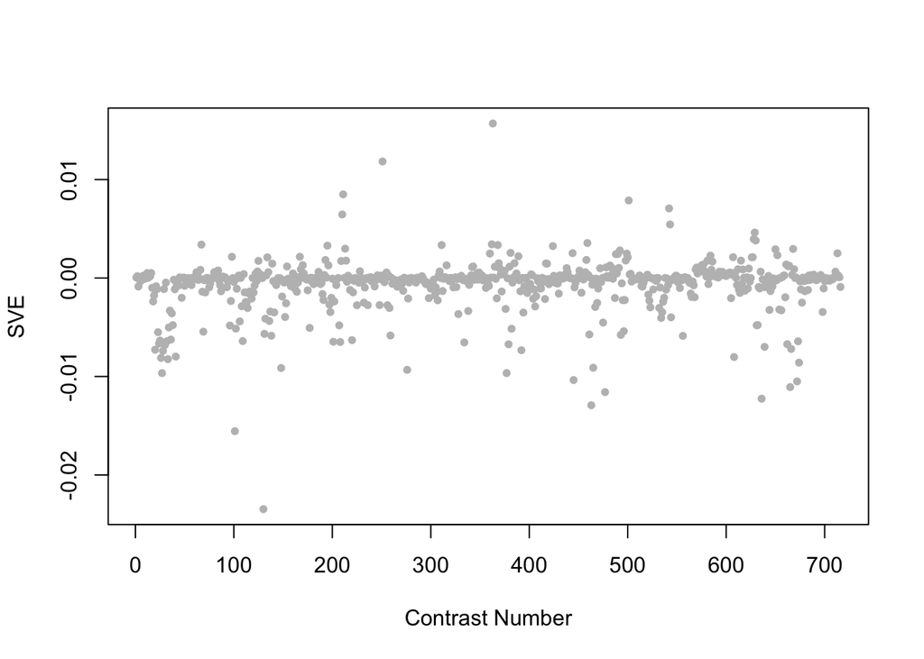

Positive SVE Contrasts:

|  | Contrast.Num | SVE | GEO.GSE | Cond.1 | Cond.2 | Mutation |
| --- | --- | --- | --- | --- | --- | --- |
| GSE36358.s2t1.vs.s0t1 | 363 | 0.02 | GSE36358 | Clino Rotation | Ground Control (Tsukuba space center) |  |
| GSE42192.s2t1.vs.s0t1 | 251 | 0.01 | GSE42192 | C.elegans fed with CNCM I-4317 3 days rep1 | C.elegans fed with E.coli OP50 3 days rep1 |  |
| GSE42689.s4t1.vs.s1t1 | 211 | 0.01 | GSE42689 | mlk-1 fed 1 | mek-1 fasted 1 |  |
| GSE23013.s1t1.vs.s0t1 | 501 | 0.01 | GSE23013 | young adult_24hr Toluene exposure_rep1 | young adult_not exposed_rep1 |  |
| GSE2180.s3t2.vs.s2t2 | 542 | 0.01 | GSE2180 | p23-2 | ms23-1 |  |

Negative SVE Contrasts:

|  | Contrast.Num | SVE | GEO.GSE | Cond.1 | Cond.2 | Mutation |
| --- | --- | --- | --- | --- | --- | --- |
| GSE52064.s4t1.vs.s3t1 | 130 | -0.02 | GSE52064 | lin-54;mes-4_1 | lin-54_1 | mes-4 |
| GSE5793.s1t2.vs.s1t1 | 101 | -0.02 | GSE5793 | Celegans_gacA_8hours_RepA | Celegans_gacA_4hours_RepA |  |
| GSE23528A.s1t4.vs.s0t4 | 463 | -0.01 | GSE23528 | Adult at T14 in LD, time-series experiment 3 | Adult at T14, non-entrained control time-series experiment 4 |  |
| GSE18132.s2t2.vs.s0t2 | 636 | -0.01 | GSE18132 | Oga Fed L4, biological replicate 1 | WT Fed L4, biological rep1 | oga-1 |
| GSE23528A.s1t2.vs.s1t1 | 477 | -0.01 | GSE23528 | Adult at T6 in LD, time-series experiment 3 | Adult at T2 in LD, time-series experiment 3 |  |

$~$

$~$

#### GO Term Enrichment:

This analysis tests each hemi-module for enrichment of specific GO terms. Only gene-level annotations (e.g., as would be found on the gene’s page in Wormbase) are tested - the hierarchical structure of the GO ontology is not taken into account.

*Note: At least the top two most enriched terms from each GO domain (BP/MF/CC) are shown, even when not statistically significant.*

##### Enriched GO terms: Hemi-module A

| ID | GO.Term | GO Domain | Raw p-value | Adj p-value |
| --- | --- | --- | --- | --- |
| [GO_0014056](http://amigo.geneontology.org/amigo/term/GO:0014056) | regulation of acetylcholine secretion, neurotransmission | BP | 5.98e-03 | 9.97e-01 |
| [GO_0014722](http://amigo.geneontology.org/amigo/term/GO:0014722) | regulation of skeletal muscle contraction by calcium ion signaling | BP | 5.98e-03 | 9.97e-01 |
| [GO_0016705](http://amigo.geneontology.org/amigo/term/GO:0016705) | oxidoreductase activity, acting on paired donors, with incorporation or reduction of molecular oxygen | MF | 1.32e-03 | 1.00e+00 |
| [GO_0004497](http://amigo.geneontology.org/amigo/term/GO:0004497) | monooxygenase activity | MF | 1.96e-03 | 1.00e+00 |
| [GO_0031672](http://amigo.geneontology.org/amigo/term/GO:0031672) | A band | CC | 1.24e-03 | 9.98e-01 |
| [GO_0005883](http://amigo.geneontology.org/amigo/term/GO:0005883) | neurofilament | CC | 5.98e-03 | 9.98e-01 |

##### Enriched GO terms: Hemi-module B

| ID | GO.Term | GO Domain | Raw p-value | Adj p-value |
| --- | --- | --- | --- | --- |
| [GO_0048557](http://amigo.geneontology.org/amigo/term/GO:0048557) | embryonic digestive tract morphogenesis | BP | 3.01e-03 | 9.99e-01 |
| [GO_0003006](http://amigo.geneontology.org/amigo/term/GO:0003006) | developmental process involved in reproduction | BP | 3.74e-03 | 9.99e-01 |
| [GO_0035497](http://amigo.geneontology.org/amigo/term/GO:0035497) | cAMP response element binding | MF | 3.74e-03 | 1.00e+00 |
| [GO_0005272](http://amigo.geneontology.org/amigo/term/GO:0005272) | sodium channel activity | MF | 5.94e-03 | 1.00e+00 |
| [GO_0030014](http://amigo.geneontology.org/amigo/term/GO:0030014) | CCR4-NOT complex | CC | 2.22e-02 | 1.00e+00 |
| [GO_0016021](http://amigo.geneontology.org/amigo/term/GO:0016021) | integral component of membrane | CC | 2.48e-02 | 1.00e+00 |

$~$

$~$

#### Tissue Enrichment:

This analysis tests each hemi-module for enrichment of genes associated with anatomy terms. Negative enrichment scores indicate fewer hemi-module genes than expected by random chance were associated with the anatomy term in question.

##### Enriched tissues: Hemi-module A

No significant annotations.

##### Enriched tissues: Hemi-module B

| ID | Anatomy.Term | Definition | Raw p-value | Adj p-value |
| --- | --- | --- | --- | --- |
| [WBbt_0004412](https://wormbase.org/species/all/anatomy_term/WBbt:0004412) | P9/10L | Cell of lineage ABplapapap, born in embryo, one of a group of postembryonic blast cells for ventral cord motorneurons, ventral hypodermis, vulva, male preanal ganglion; ventral hypodermis in L1. | 4.54e-05 | 4.83e-02 |
| [WBbt_0005904](https://wormbase.org/species/all/anatomy_term/WBbt:0005904) | ABaraaaaaa | embryonic cell | 5.96e-05 | 4.83e-02 |
| [WBbt_0006558](https://wormbase.org/species/all/anatomy_term/WBbt:0006558) | ABaraaaaap | embryonic cell | 5.96e-05 | 4.83e-02 |
| [WBbt_0005863](https://wormbase.org/species/all/anatomy_term/WBbt:0005863) | ABalapappa | embryonic cell | 1.25e-04 | 6.00e-02 |
| [WBbt_0006616](https://wormbase.org/species/all/anatomy_term/WBbt:0006616) | ABalapappp | embryonic cell | 2.13e-04 | 6.00e-02 |
| [WBbt_0004671](https://wormbase.org/species/all/anatomy_term/WBbt:0004671) | hyp7 | Embryonic cell of pedigree ABplappppa, precursor of embryonic large hypodermal syncytium. | 2.66e-04 | 6.00e-02 |
| [WBbt_0006238](https://wormbase.org/species/all/anatomy_term/WBbt:0006238) | ABalpapppp | embryonic cell | 2.66e-04 | 6.00e-02 |
| [WBbt_0006655](https://wormbase.org/species/all/anatomy_term/WBbt:0006655) | ABaraaappp | embryonic cell | 3.25e-04 | 6.00e-02 |
| [WBbt_0004353](https://wormbase.org/species/all/anatomy_term/WBbt:0004353) | int2D | Intestinal cell | 3.90e-04 | 6.00e-02 |
| [WBbt_0005975](https://wormbase.org/species/all/anatomy_term/WBbt:0005975) | ABalppappa | embryonic cell | 3.90e-04 | 6.00e-02 |
| [WBbt_0005999](https://wormbase.org/species/all/anatomy_term/WBbt:0005999) | ABaraapapp | embryonic cell | 4.60e-04 | 6.00e-02 |
| [WBbt_0005927](https://wormbase.org/species/all/anatomy_term/WBbt:0005927) | ABplappaap | embryonic cell | 5.36e-04 | 6.00e-02 |
| [WBbt_0006577](https://wormbase.org/species/all/anatomy_term/WBbt:0006577) | ABplappaaa | embryonic cell | 5.36e-04 | 6.00e-02 |
| [WBbt_0006638](https://wormbase.org/species/all/anatomy_term/WBbt:0006638) | ABalpppppa | embryonic cell | 5.36e-04 | 6.00e-02 |
| [WBbt_0006701](https://wormbase.org/species/all/anatomy_term/WBbt:0006701) | ABalpapppa | embryonic cell | 5.36e-04 | 6.00e-02 |
| [WBbt_0005857](https://wormbase.org/species/all/anatomy_term/WBbt:0005857) | MSapaaa | embryonic cell | 6.17e-04 | 6.00e-02 |
| [WBbt_0005925](https://wormbase.org/species/all/anatomy_term/WBbt:0005925) | MSppaaa | embryonic cell | 6.17e-04 | 6.00e-02 |
| [WBbt_0006239](https://wormbase.org/species/all/anatomy_term/WBbt:0006239) | MSapapa | embryonic cell | 6.17e-04 | 6.00e-02 |
| [WBbt_0006107](https://wormbase.org/species/all/anatomy_term/WBbt:0006107) | MSapppp | embryonic cell | 7.04e-04 | 6.00e-02 |
| [WBbt_0006042](https://wormbase.org/species/all/anatomy_term/WBbt:0006042) | MSapppa | embryonic cell | 7.97e-04 | 6.00e-02 |
| [WBbt_0006072](https://wormbase.org/species/all/anatomy_term/WBbt:0006072) | MSapaap | embryonic cell | 7.97e-04 | 6.00e-02 |
| [WBbt_0006324](https://wormbase.org/species/all/anatomy_term/WBbt:0006324) | ABplappapp | embryonic cell | 7.97e-04 | 6.00e-02 |
| [WBbt_0006445](https://wormbase.org/species/all/anatomy_term/WBbt:0006445) | ABaraapaaa | embryonic cell | 7.97e-04 | 6.00e-02 |
| [WBbt_0006492](https://wormbase.org/species/all/anatomy_term/WBbt:0006492) | MSapapp | embryonic cell | 7.97e-04 | 6.00e-02 |
| [WBbt_0006734](https://wormbase.org/species/all/anatomy_term/WBbt:0006734) | MSpppaa | embryonic cell | 8.95e-04 | 6.00e-02 |
| [WBbt_0005964](https://wormbase.org/species/all/anatomy_term/WBbt:0005964) | Cppaa | embryonic cell | 9.99e-04 | 6.00e-02 |
| [WBbt_0006174](https://wormbase.org/species/all/anatomy_term/WBbt:0006174) | MSpppap | embryonic cell | 9.99e-04 | 6.00e-02 |
| [WBbt_0006636](https://wormbase.org/species/all/anatomy_term/WBbt:0006636) | ABaraappaa | embryonic cell | 9.99e-04 | 6.00e-02 |
| [WBbt_0005973](https://wormbase.org/species/all/anatomy_term/WBbt:0005973) | ABarapaap | embryonic cell | 1.11e-03 | 6.00e-02 |
| [WBbt_0006078](https://wormbase.org/species/all/anatomy_term/WBbt:0006078) | MSaaaaa | embryonic cell | 1.11e-03 | 6.00e-02 |

[output cut: 134 more lines]

$~$

$~$

#### HOMER promoter motif enrichment:

This analysis tests each hemi-module for enrichment of 108 known *C. elegans* transcription factor binding site motifs (see [108 CE motifs](https://katiepod.github.io//all.worm.motifs.html)) using the HOMER (Hypergeometric Optimization of Motif EnRichment) software (see [PMID:20513432](https://pubmed.ncbi.nlm.nih.gov/20513432)). HOMER was run using default parameters on sequences 1 kb upstream of the transcription start site.

##### Motif enrichment: Hemi-module A

Total target sequences = 101  
Total background sequences = 39286  
* - possible false positive

Rank

Motif

P-value

log P-pvalue

% of Targets

% of Background

STD(Bg STD)

Best Match/Details

Motif File

1 *

[figure not shown]

1e-10

-2.507e+01

9.90%

0.38%

282.2bp (311.0bp)

efl-1/MA0541.1/Jaspar(0.536)  
[More Information](https://katiepod.github.io/HomerResults/m44_a_hemi_genes.txt.out.1kb/homerResults/motif1.info.html) | [Similar Motifs Found](https://katiepod.github.io/HomerResults/m44_a_hemi_genes.txt.out.1kb/homerResults/motif1.similar.html)

[motif file (matrix)](https://katiepod.github.io/HomerResults/m44_a_hemi_genes.txt.out.1kb/homerResults/motif1.motif)

2 *

[figure not shown]

1e-10

-2.348e+01

10.89%

0.62%

274.1bp (306.2bp)

unc-86/MA0926.1/Jaspar(0.553)  
[More Information](https://katiepod.github.io/HomerResults/m44_a_hemi_genes.txt.out.1kb/homerResults/motif2.info.html) | [Similar Motifs Found](https://katiepod.github.io/HomerResults/m44_a_hemi_genes.txt.out.1kb/homerResults/motif2.similar.html)

[motif file (matrix)](https://katiepod.github.io/HomerResults/m44_a_hemi_genes.txt.out.1kb/homerResults/motif2.motif)

3 *

[figure not shown]

1e-10

-2.317e+01

6.93%

0.12%

375.2bp (284.8bp)

snpc-4/MA0544.1/Jaspar(0.572)  
[More Information](https://katiepod.github.io/HomerResults/m44_a_hemi_genes.txt.out.1kb/homerResults/motif3.info.html) | [Similar Motifs Found](https://katiepod.github.io/HomerResults/m44_a_hemi_genes.txt.out.1kb/homerResults/motif3.similar.html)

[motif file (matrix)](https://katiepod.github.io/HomerResults/m44_a_hemi_genes.txt.out.1kb/homerResults/motif3.motif)

4 *

[figure not shown]

1e-9

-2.088e+01

12.87%

1.29%

297.3bp (310.4bp)

blmp-1/MA0537.1/Jaspar(0.621)  
[More Information](https://katiepod.github.io/HomerResults/m44_a_hemi_genes.txt.out.1kb/homerResults/motif4.info.html) | [Similar Motifs Found](https://katiepod.github.io/HomerResults/m44_a_hemi_genes.txt.out.1kb/homerResults/motif4.similar.html)

[motif file (matrix)](https://katiepod.github.io/HomerResults/m44_a_hemi_genes.txt.out.1kb/homerResults/motif4.motif)

5 *

[figure not shown]

1e-8

-2.040e+01

9.90%

0.63%

242.6bp (329.3bp)

cebp-1/MA1444.1/Jaspar(0.677)  
[More Information](https://katiepod.github.io/HomerResults/m44_a_hemi_genes.txt.out.1kb/homerResults/motif5.info.html) | [Similar Motifs Found](https://katiepod.github.io/HomerResults/m44_a_hemi_genes.txt.out.1kb/homerResults/motif5.similar.html)

[motif file (matrix)](https://katiepod.github.io/HomerResults/m44_a_hemi_genes.txt.out.1kb/homerResults/motif5.motif)

6 *

[figure not shown]

1e-8

-1.958e+01

6.93%

0.21%

325.4bp (291.5bp)

SD0001.1_at_AC_acceptor/Jaspar(0.584)  
[More Information](https://katiepod.github.io/HomerResults/m44_a_hemi_genes.txt.out.1kb/homerResults/motif6.info.html) | [Similar Motifs Found](https://katiepod.github.io/HomerResults/m44_a_hemi_genes.txt.out.1kb/homerResults/motif6.similar.html)

[motif file (matrix)](https://katiepod.github.io/HomerResults/m44_a_hemi_genes.txt.out.1kb/homerResults/motif6.motif)

7 *

[figure not shown]

1e-8

-1.943e+01

10.89%

0.93%

280.0bp (315.7bp)

ceh-48/MA0921.1/Jaspar(0.610)  
[More Information](https://katiepod.github.io/HomerResults/m44_a_hemi_genes.txt.out.1kb/homerResults/motif7.info.html) | [Similar Motifs Found](https://katiepod.github.io/HomerResults/m44_a_hemi_genes.txt.out.1kb/homerResults/motif7.similar.html)

[motif file (matrix)](https://katiepod.github.io/HomerResults/m44_a_hemi_genes.txt.out.1kb/homerResults/motif7.motif)

8 *

[figure not shown]

1e-8

-1.882e+01

22.77%

5.56%

282.3bp (313.2bp)

lin-54/MA1450.1/Jaspar(0.573)  
[More Information](https://katiepod.github.io/HomerResults/m44_a_hemi_genes.txt.out.1kb/homerResults/motif8.info.html) | [Similar Motifs Found](https://katiepod.github.io/HomerResults/m44_a_hemi_genes.txt.out.1kb/homerResults/motif8.similar.html)

[motif file (matrix)](https://katiepod.github.io/HomerResults/m44_a_hemi_genes.txt.out.1kb/homerResults/motif8.motif)

9 *

[figure not shown]

1e-7

-1.816e+01

9.90%

0.81%

371.0bp (321.0bp)

pal-1/MA0924.1/Jaspar(0.603)  
[More Information](https://katiepod.github.io/HomerResults/m44_a_hemi_genes.txt.out.1kb/homerResults/motif9.info.html) | [Similar Motifs Found](https://katiepod.github.io/HomerResults/m44_a_hemi_genes.txt.out.1kb/homerResults/motif9.similar.html)

[motif file (matrix)](https://katiepod.github.io/HomerResults/m44_a_hemi_genes.txt.out.1kb/homerResults/motif9.motif)

10 *

[figure not shown]

1e-7

-1.787e+01

16.83%

3.11%

224.8bp (340.7bp)

skn-1/MA0547.1/Jaspar(0.613)  
[More Information](https://katiepod.github.io/HomerResults/m44_a_hemi_genes.txt.out.1kb/homerResults/motif10.info.html) | [Similar Motifs Found](https://katiepod.github.io/HomerResults/m44_a_hemi_genes.txt.out.1kb/homerResults/motif10.similar.html)

[motif file (matrix)](https://katiepod.github.io/HomerResults/m44_a_hemi_genes.txt.out.1kb/homerResults/motif10.motif)

11 *

[figure not shown]

1e-7

-1.780e+01

15.84%

2.73%

333.7bp (324.6bp)

skn-1/MA0547.1/Jaspar(0.695)  
[More Information](https://katiepod.github.io/HomerResults/m44_a_hemi_genes.txt.out.1kb/homerResults/motif11.info.html) | [Similar Motifs Found](https://katiepod.github.io/HomerResults/m44_a_hemi_genes.txt.out.1kb/homerResults/motif11.similar.html)

[motif file (matrix)](https://katiepod.github.io/HomerResults/m44_a_hemi_genes.txt.out.1kb/homerResults/motif11.motif)

12 *

[figure not shown]

1e-7

-1.775e+01

10.89%

1.09%

308.0bp (331.0bp)

daf-16/MA1446.1/Jaspar(0.678)  
[More Information](https://katiepod.github.io/HomerResults/m44_a_hemi_genes.txt.out.1kb/homerResults/motif12.info.html) | [Similar Motifs Found](https://katiepod.github.io/HomerResults/m44_a_hemi_genes.txt.out.1kb/homerResults/motif12.similar.html)

[motif file (matrix)](https://katiepod.github.io/HomerResults/m44_a_hemi_genes.txt.out.1kb/homerResults/motif12.motif)

13 *

[figure not shown]

1e-7

-1.760e+01

7.92%

0.44%

317.8bp (300.4bp)

MF0001.1_ETS_class/Jaspar(0.595)  
[More Information](https://katiepod.github.io/HomerResults/m44_a_hemi_genes.txt.out.1kb/homerResults/motif13.info.html) | [Similar Motifs Found](https://katiepod.github.io/HomerResults/m44_a_hemi_genes.txt.out.1kb/homerResults/motif13.similar.html)

[motif file (matrix)](https://katiepod.github.io/HomerResults/m44_a_hemi_genes.txt.out.1kb/homerResults/motif13.motif)

14 *

[figure not shown]

1e-7

-1.758e+01

12.87%

1.71%

320.6bp (308.7bp)

POL008.1_DCE_S_I/Jaspar(0.693)  
[More Information](https://katiepod.github.io/HomerResults/m44_a_hemi_genes.txt.out.1kb/homerResults/motif14.info.html) | [Similar Motifs Found](https://katiepod.github.io/HomerResults/m44_a_hemi_genes.txt.out.1kb/homerResults/motif14.similar.html)

[motif file (matrix)](https://katiepod.github.io/HomerResults/m44_a_hemi_genes.txt.out.1kb/homerResults/motif14.motif)

15 *

[figure not shown]

1e-6

-1.542e+01

4.95%

0.12%

331.8bp (311.4bp)

POL012.1_TATA-Box/Jaspar(0.576)  
[More Information](https://katiepod.github.io/HomerResults/m44_a_hemi_genes.txt.out.1kb/homerResults/motif15.info.html) | [Similar Motifs Found](https://katiepod.github.io/HomerResults/m44_a_hemi_genes.txt.out.1kb/homerResults/motif15.similar.html)

[motif file (matrix)](https://katiepod.github.io/HomerResults/m44_a_hemi_genes.txt.out.1kb/homerResults/motif15.motif)

16 *

[figure not shown]

1e-6

-1.508e+01

5.94%

0.25%

268.7bp (284.4bp)

SD0003.1_at_AC_acceptor/Jaspar(0.527)  
[More Information](https://katiepod.github.io/HomerResults/m44_a_hemi_genes.txt.out.1kb/homerResults/motif16.info.html) | [Similar Motifs Found](https://katiepod.github.io/HomerResults/m44_a_hemi_genes.txt.out.1kb/homerResults/motif16.similar.html)

[motif file (matrix)](https://katiepod.github.io/HomerResults/m44_a_hemi_genes.txt.out.1kb/homerResults/motif16.motif)

17 *

[figure not shown]

1e-6

-1.483e+01

18.81%

4.82%

276.8bp (329.5bp)

ceh-22/MA0264.1/Jaspar(0.577)  
[More Information](https://katiepod.github.io/HomerResults/m44_a_hemi_genes.txt.out.1kb/homerResults/motif17.info.html) | [Similar Motifs Found](https://katiepod.github.io/HomerResults/m44_a_hemi_genes.txt.out.1kb/homerResults/motif17.similar.html)

[motif file (matrix)](https://katiepod.github.io/HomerResults/m44_a_hemi_genes.txt.out.1kb/homerResults/motif17.motif)

18 *

[figure not shown]

1e-6

-1.409e+01

3.96%

0.06%

167.4bp (193.4bp)

ceh-10::ttx-3/MA0263.1/Jaspar(0.619)  
[More Information](https://katiepod.github.io/HomerResults/m44_a_hemi_genes.txt.out.1kb/homerResults/motif18.info.html) | [Similar Motifs Found](https://katiepod.github.io/HomerResults/m44_a_hemi_genes.txt.out.1kb/homerResults/motif18.similar.html)

[motif file (matrix)](https://katiepod.github.io/HomerResults/m44_a_hemi_genes.txt.out.1kb/homerResults/motif18.motif)

19 *

[figure not shown]

1e-6

-1.385e+01

12.87%

2.38%

256.3bp (320.8bp)

PHA-4(Forkhead)/cElegans-Embryos-PHA4-ChIP-Seq(modEncode)/Homer(0.538)  
[More Information](https://katiepod.github.io/HomerResults/m44_a_hemi_genes.txt.out.1kb/homerResults/motif19.info.html) | [Similar Motifs Found](https://katiepod.github.io/HomerResults/m44_a_hemi_genes.txt.out.1kb/homerResults/motif19.similar.html)

[motif file (matrix)](https://katiepod.github.io/HomerResults/m44_a_hemi_genes.txt.out.1kb/homerResults/motif19.motif)

20 *

[figure not shown]

1e-5

-1.354e+01

4.95%

0.17%

252.7bp (275.1bp)

ceh-28/MA1445.1/Jaspar(0.546)  
[More Information](https://katiepod.github.io/HomerResults/m44_a_hemi_genes.txt.out.1kb/homerResults/motif20.info.html) | [Similar Motifs Found](https://katiepod.github.io/HomerResults/m44_a_hemi_genes.txt.out.1kb/homerResults/motif20.similar.html)

[motif file (matrix)](https://katiepod.github.io/HomerResults/m44_a_hemi_genes.txt.out.1kb/homerResults/motif20.motif)

21 *

[figure not shown]

1e-5

-1.349e+01

7.92%

0.76%

283.3bp (305.3bp)

POL008.1_DCE_S_I/Jaspar(0.600)  
[More Information](https://katiepod.github.io/HomerResults/m44_a_hemi_genes.txt.out.1kb/homerResults/motif21.info.html) | [Similar Motifs Found](https://katiepod.github.io/HomerResults/m44_a_hemi_genes.txt.out.1kb/homerResults/motif21.similar.html)

[motif file (matrix)](https://katiepod.github.io/HomerResults/m44_a_hemi_genes.txt.out.1kb/homerResults/motif21.motif)

22 *

[figure not shown]

1e-5

-1.341e+01

3.96%

0.07%

160.1bp (315.1bp)

snpc-4/MA0544.1/Jaspar(0.504)  
[More Information](https://katiepod.github.io/HomerResults/m44_a_hemi_genes.txt.out.1kb/homerResults/motif22.info.html) | [Similar Motifs Found](https://katiepod.github.io/HomerResults/m44_a_hemi_genes.txt.out.1kb/homerResults/motif22.similar.html)

[motif file (matrix)](https://katiepod.github.io/HomerResults/m44_a_hemi_genes.txt.out.1kb/homerResults/motif22.motif)

23 *

[figure not shown]

1e-5

-1.294e+01

9.90%

1.44%

262.8bp (317.0bp)

PL0013.1_hlh-2::hlh-15/Jaspar(0.690)  
[More Information](https://katiepod.github.io/HomerResults/m44_a_hemi_genes.txt.out.1kb/homerResults/motif23.info.html) | [Similar Motifs Found](https://katiepod.github.io/HomerResults/m44_a_hemi_genes.txt.out.1kb/homerResults/motif23.similar.html)

[motif file (matrix)](https://katiepod.github.io/HomerResults/m44_a_hemi_genes.txt.out.1kb/homerResults/motif23.motif)

24 *

[figure not shown]

1e-5

-1.273e+01

18.81%

5.56%

226.8bp (314.8bp)

unc-62/MA0918.1/Jaspar(0.643)  
[More Information](https://katiepod.github.io/HomerResults/m44_a_hemi_genes.txt.out.1kb/homerResults/motif24.info.html) | [Similar Motifs Found](https://katiepod.github.io/HomerResults/m44_a_hemi_genes.txt.out.1kb/homerResults/motif24.similar.html)

[motif file (matrix)](https://katiepod.github.io/HomerResults/m44_a_hemi_genes.txt.out.1kb/homerResults/motif24.motif)

25 *

[figure not shown]

1e-5

-1.208e+01

19.80%

6.38%

233.5bp (322.6bp)

lin-54/MA1450.1/Jaspar(0.607)  
[More Information](https://katiepod.github.io/HomerResults/m44_a_hemi_genes.txt.out.1kb/homerResults/motif25.info.html) | [Similar Motifs Found](https://katiepod.github.io/HomerResults/m44_a_hemi_genes.txt.out.1kb/homerResults/motif25.similar.html)

[motif file (matrix)](https://katiepod.github.io/HomerResults/m44_a_hemi_genes.txt.out.1kb/homerResults/motif25.motif)

26 *

[figure not shown]

1e-4

-1.119e+01

9.90%

1.77%

197.3bp (317.2bp)

PL0013.1_hlh-2::hlh-15/Jaspar(0.566)  
[More Information](https://katiepod.github.io/HomerResults/m44_a_hemi_genes.txt.out.1kb/homerResults/motif26.info.html) | [Similar Motifs Found](https://katiepod.github.io/HomerResults/m44_a_hemi_genes.txt.out.1kb/homerResults/motif26.similar.html)

[motif file (matrix)](https://katiepod.github.io/HomerResults/m44_a_hemi_genes.txt.out.1kb/homerResults/motif26.motif)

27 *

[figure not shown]

1e-4

-1.100e+01

21.78%

8.09%

228.5bp (327.0bp)

POL012.1_TATA-Box/Jaspar(0.604)  
[More Information](https://katiepod.github.io/HomerResults/m44_a_hemi_genes.txt.out.1kb/homerResults/motif27.info.html) | [Similar Motifs Found](https://katiepod.github.io/HomerResults/m44_a_hemi_genes.txt.out.1kb/homerResults/motif27.similar.html)

[motif file (matrix)](https://katiepod.github.io/HomerResults/m44_a_hemi_genes.txt.out.1kb/homerResults/motif27.motif)

28 *

[figure not shown]

1e-4

-1.081e+01

2.97%

0.05%

167.5bp (316.6bp)

POL010.1_DCE_S_III/Jaspar(0.495)  
[More Information](https://katiepod.github.io/HomerResults/m44_a_hemi_genes.txt.out.1kb/homerResults/motif28.info.html) | [Similar Motifs Found](https://katiepod.github.io/HomerResults/m44_a_hemi_genes.txt.out.1kb/homerResults/motif28.similar.html)

[motif file (matrix)](https://katiepod.github.io/HomerResults/m44_a_hemi_genes.txt.out.1kb/homerResults/motif28.motif)

29 *

[figure not shown]

1e-4

-1.030e+01

14.85%

4.35%

208.5bp (320.2bp)

CES-1(Homeobox)/cElegans-L1-CES1-ChIP-Seq(modEncode)/Homer(0.584)  
[More Information](https://katiepod.github.io/HomerResults/m44_a_hemi_genes.txt.out.1kb/homerResults/motif29.info.html) | [Similar Motifs Found](https://katiepod.github.io/HomerResults/m44_a_hemi_genes.txt.out.1kb/homerResults/motif29.similar.html)

[motif file (matrix)](https://katiepod.github.io/HomerResults/m44_a_hemi_genes.txt.out.1kb/homerResults/motif29.motif)

30 *

[figure not shown]

1e-4

-9.621e+00

14.85%

4.62%

237.4bp (327.9bp)

fos-1/MA1448.1/Jaspar(0.762)  
[More Information](https://katiepod.github.io/HomerResults/m44_a_hemi_genes.txt.out.1kb/homerResults/motif30.info.html) | [Similar Motifs Found](https://katiepod.github.io/HomerResults/m44_a_hemi_genes.txt.out.1kb/homerResults/motif30.similar.html)

[motif file (matrix)](https://katiepod.github.io/HomerResults/m44_a_hemi_genes.txt.out.1kb/homerResults/motif30.motif)

31 *

[figure not shown]

1e-4

-9.416e+00

2.97%

0.08%

259.0bp (342.4bp)

ceh-22/MA0264.1/Jaspar(0.594)  
[More Information](https://katiepod.github.io/HomerResults/m44_a_hemi_genes.txt.out.1kb/homerResults/motif31.info.html) | [Similar Motifs Found](https://katiepod.github.io/HomerResults/m44_a_hemi_genes.txt.out.1kb/homerResults/motif31.similar.html)

[motif file (matrix)](https://katiepod.github.io/HomerResults/m44_a_hemi_genes.txt.out.1kb/homerResults/motif31.motif)

32 *

[figure not shown]

1e-3

-9.015e+00

41.58%

24.50%

302.0bp (322.1bp)

MF0001.1_ETS_class/Jaspar(0.682)  
[More Information](https://katiepod.github.io/HomerResults/m44_a_hemi_genes.txt.out.1kb/homerResults/motif32.info.html) | [Similar Motifs Found](https://katiepod.github.io/HomerResults/m44_a_hemi_genes.txt.out.1kb/homerResults/motif32.similar.html)

[motif file (matrix)](https://katiepod.github.io/HomerResults/m44_a_hemi_genes.txt.out.1kb/homerResults/motif32.motif)

33 *

[figure not shown]

1e-3

-8.706e+00

4.95%

0.49%

189.0bp (314.8bp)

POL008.1_DCE_S_I/Jaspar(0.615)  
[More Information](https://katiepod.github.io/HomerResults/m44_a_hemi_genes.txt.out.1kb/homerResults/motif33.info.html) | [Similar Motifs Found](https://katiepod.github.io/HomerResults/m44_a_hemi_genes.txt.out.1kb/homerResults/motif33.similar.html)

[motif file (matrix)](https://katiepod.github.io/HomerResults/m44_a_hemi_genes.txt.out.1kb/homerResults/motif33.motif)

34 *

[figure not shown]

1e-3

-8.483e+00

2.97%

0.11%

287.9bp (338.5bp)

POL010.1_DCE_S_III/Jaspar(0.534)  
[More Information](https://katiepod.github.io/HomerResults/m44_a_hemi_genes.txt.out.1kb/homerResults/motif34.info.html) | [Similar Motifs Found](https://katiepod.github.io/HomerResults/m44_a_hemi_genes.txt.out.1kb/homerResults/motif34.similar.html)

[motif file (matrix)](https://katiepod.github.io/HomerResults/m44_a_hemi_genes.txt.out.1kb/homerResults/motif34.motif)

35 *

[figure not shown]

1e-3

-7.770e+00

33.66%

19.19%

292.1bp (324.4bp)

POL007.1_BREd/Jaspar(0.683)  
[More Information](https://katiepod.github.io/HomerResults/m44_a_hemi_genes.txt.out.1kb/homerResults/motif35.info.html) | [Similar Motifs Found](https://katiepod.github.io/HomerResults/m44_a_hemi_genes.txt.out.1kb/homerResults/motif35.similar.html)

[motif file (matrix)](https://katiepod.github.io/HomerResults/m44_a_hemi_genes.txt.out.1kb/homerResults/motif35.motif)

36 *

[figure not shown]

1e-3

-7.335e+00

1.98%

0.03%

240.7bp (217.1bp)

POL013.1_MED-1/Jaspar(0.677)  
[More Information](https://katiepod.github.io/HomerResults/m44_a_hemi_genes.txt.out.1kb/homerResults/motif36.info.html) | [Similar Motifs Found](https://katiepod.github.io/HomerResults/m44_a_hemi_genes.txt.out.1kb/homerResults/motif36.similar.html)

[motif file (matrix)](https://katiepod.github.io/HomerResults/m44_a_hemi_genes.txt.out.1kb/homerResults/motif36.motif)

37 *

[figure not shown]

1e-2

-6.719e+00

2.97%

0.20%

260.4bp (324.7bp)

mab-5/MA1442.1/Jaspar(0.754)  
[More Information](https://katiepod.github.io/HomerResults/m44_a_hemi_genes.txt.out.1kb/homerResults/motif37.info.html) | [Similar Motifs Found](https://katiepod.github.io/HomerResults/m44_a_hemi_genes.txt.out.1kb/homerResults/motif37.similar.html)

[motif file (matrix)](https://katiepod.github.io/HomerResults/m44_a_hemi_genes.txt.out.1kb/homerResults/motif37.motif)

38 *

[figure not shown]

1e-2

-5.979e+00

0.99%

0.00%

113.1bp (0.0bp)

POL004.1_CCAAT-box/Jaspar(0.793)  
[More Information](https://katiepod.github.io/HomerResults/m44_a_hemi_genes.txt.out.1kb/homerResults/motif38.info.html) | [Similar Motifs Found](https://katiepod.github.io/HomerResults/m44_a_hemi_genes.txt.out.1kb/homerResults/motif38.similar.html)

[motif file (matrix)](https://katiepod.github.io/HomerResults/m44_a_hemi_genes.txt.out.1kb/homerResults/motif38.motif)

39 *

[figure not shown]

1e-2

-5.958e+00

2.97%

0.26%

153.5bp (300.5bp)

SD0001.1_at_AC_acceptor/Jaspar(0.508)  
[More Information](https://katiepod.github.io/HomerResults/m44_a_hemi_genes.txt.out.1kb/homerResults/motif39.info.html) | [Similar Motifs Found](https://katiepod.github.io/HomerResults/m44_a_hemi_genes.txt.out.1kb/homerResults/motif39.similar.html)

[motif file (matrix)](https://katiepod.github.io/HomerResults/m44_a_hemi_genes.txt.out.1kb/homerResults/motif39.motif)

40 *

[figure not shown]

1e-2

-5.524e+00

1.98%

0.09%

205.3bp (338.4bp)

POL001.1_MTE/Jaspar(0.617)  
[More Information](https://katiepod.github.io/HomerResults/m44_a_hemi_genes.txt.out.1kb/homerResults/motif40.info.html) | [Similar Motifs Found](https://katiepod.github.io/HomerResults/m44_a_hemi_genes.txt.out.1kb/homerResults/motif40.similar.html)

[motif file (matrix)](https://katiepod.github.io/HomerResults/m44_a_hemi_genes.txt.out.1kb/homerResults/motif40.motif)

##### Motif enrichment: Hemi-module B

Total target sequences = 62  
Total background sequences = 39815  
* - possible false positive

Rank

Motif

P-value

log P-pvalue

% of Targets

% of Background

STD(Bg STD)

Best Match/Details

Motif File

1 *

[figure not shown]

1e-9

-2.192e+01

9.68%

0.12%

235.0bp (292.9bp)

ceh-38/MA1699.1/Jaspar(0.518)  
[More Information](https://katiepod.github.io/HomerResults/m44_b_hemi_genes.txt.out.1kb/homerResults/motif1.info.html) | [Similar Motifs Found](https://katiepod.github.io/HomerResults/m44_b_hemi_genes.txt.out.1kb/homerResults/motif1.similar.html)

[motif file (matrix)](https://katiepod.github.io/HomerResults/m44_b_hemi_genes.txt.out.1kb/homerResults/motif1.motif)

2 *

[figure not shown]

1e-8

-2.000e+01

9.68%

0.17%

214.2bp (286.3bp)

fkh-9/MA1440.1/Jaspar(0.667)  
[More Information](https://katiepod.github.io/HomerResults/m44_b_hemi_genes.txt.out.1kb/homerResults/motif2.info.html) | [Similar Motifs Found](https://katiepod.github.io/HomerResults/m44_b_hemi_genes.txt.out.1kb/homerResults/motif2.similar.html)

[motif file (matrix)](https://katiepod.github.io/HomerResults/m44_b_hemi_genes.txt.out.1kb/homerResults/motif2.motif)

3 *

[figure not shown]

1e-8

-1.953e+01

27.42%

4.76%

317.8bp (297.5bp)

cebp-1/MA1444.1/Jaspar(0.656)  
[More Information](https://katiepod.github.io/HomerResults/m44_b_hemi_genes.txt.out.1kb/homerResults/motif3.info.html) | [Similar Motifs Found](https://katiepod.github.io/HomerResults/m44_b_hemi_genes.txt.out.1kb/homerResults/motif3.similar.html)

[motif file (matrix)](https://katiepod.github.io/HomerResults/m44_b_hemi_genes.txt.out.1kb/homerResults/motif3.motif)

4 *

[figure not shown]

1e-8

-1.907e+01

27.42%

4.91%

327.1bp (314.8bp)

zfh-2/MA0928.1/Jaspar(0.645)  
[More Information](https://katiepod.github.io/HomerResults/m44_b_hemi_genes.txt.out.1kb/homerResults/motif4.info.html) | [Similar Motifs Found](https://katiepod.github.io/HomerResults/m44_b_hemi_genes.txt.out.1kb/homerResults/motif4.similar.html)

[motif file (matrix)](https://katiepod.github.io/HomerResults/m44_b_hemi_genes.txt.out.1kb/homerResults/motif4.motif)

5 *

[figure not shown]

1e-8

-1.887e+01

17.74%

1.65%

256.2bp (307.6bp)

POL008.1_DCE_S_I/Jaspar(0.610)  
[More Information](https://katiepod.github.io/HomerResults/m44_b_hemi_genes.txt.out.1kb/homerResults/motif5.info.html) | [Similar Motifs Found](https://katiepod.github.io/HomerResults/m44_b_hemi_genes.txt.out.1kb/homerResults/motif5.similar.html)

[motif file (matrix)](https://katiepod.github.io/HomerResults/m44_b_hemi_genes.txt.out.1kb/homerResults/motif5.motif)

6 *

[figure not shown]

1e-8

-1.879e+01

14.52%

0.92%

283.4bp (304.0bp)

cebp-1/MA1444.1/Jaspar(0.605)  
[More Information](https://katiepod.github.io/HomerResults/m44_b_hemi_genes.txt.out.1kb/homerResults/motif6.info.html) | [Similar Motifs Found](https://katiepod.github.io/HomerResults/m44_b_hemi_genes.txt.out.1kb/homerResults/motif6.similar.html)

[motif file (matrix)](https://katiepod.github.io/HomerResults/m44_b_hemi_genes.txt.out.1kb/homerResults/motif6.motif)

7 *

[figure not shown]

1e-7

-1.838e+01

20.97%

2.70%

295.8bp (302.0bp)

SD0001.1_at_AC_acceptor/Jaspar(0.602)  
[More Information](https://katiepod.github.io/HomerResults/m44_b_hemi_genes.txt.out.1kb/homerResults/motif7.info.html) | [Similar Motifs Found](https://katiepod.github.io/HomerResults/m44_b_hemi_genes.txt.out.1kb/homerResults/motif7.similar.html)

[motif file (matrix)](https://katiepod.github.io/HomerResults/m44_b_hemi_genes.txt.out.1kb/homerResults/motif7.motif)

8 *

[figure not shown]

1e-7

-1.741e+01

33.87%

8.66%

251.1bp (593.7bp)

fkh-9/MA1440.1/Jaspar(0.647)  
[More Information](https://katiepod.github.io/HomerResults/m44_b_hemi_genes.txt.out.1kb/homerResults/motif8.info.html) | [Similar Motifs Found](https://katiepod.github.io/HomerResults/m44_b_hemi_genes.txt.out.1kb/homerResults/motif8.similar.html)

[motif file (matrix)](https://katiepod.github.io/HomerResults/m44_b_hemi_genes.txt.out.1kb/homerResults/motif8.motif)

9 *

[figure not shown]

1e-7

-1.736e+01

9.68%

0.28%

303.8bp (294.7bp)

CES-1(Homeobox)/cElegans-L1-CES1-ChIP-Seq(modEncode)/Homer(0.630)  
[More Information](https://katiepod.github.io/HomerResults/m44_b_hemi_genes.txt.out.1kb/homerResults/motif9.info.html) | [Similar Motifs Found](https://katiepod.github.io/HomerResults/m44_b_hemi_genes.txt.out.1kb/homerResults/motif9.similar.html)

[motif file (matrix)](https://katiepod.github.io/HomerResults/m44_b_hemi_genes.txt.out.1kb/homerResults/motif9.motif)

10 *

[figure not shown]

1e-7

-1.717e+01

24.19%

4.21%

240.1bp (308.5bp)

MF0005.1_Forkhead_class/Jaspar(0.597)  
[More Information](https://katiepod.github.io/HomerResults/m44_b_hemi_genes.txt.out.1kb/homerResults/motif10.info.html) | [Similar Motifs Found](https://katiepod.github.io/HomerResults/m44_b_hemi_genes.txt.out.1kb/homerResults/motif10.similar.html)

[motif file (matrix)](https://katiepod.github.io/HomerResults/m44_b_hemi_genes.txt.out.1kb/homerResults/motif10.motif)

11 *

[figure not shown]

1e-7

-1.691e+01

22.58%

3.66%

298.4bp (301.2bp)

LIN-39(Homeobox)/cElegans.L3-LIN39-ChIP-Seq(modEncode)/Homer(0.585)  
[More Information](https://katiepod.github.io/HomerResults/m44_b_hemi_genes.txt.out.1kb/homerResults/motif11.info.html) | [Similar Motifs Found](https://katiepod.github.io/HomerResults/m44_b_hemi_genes.txt.out.1kb/homerResults/motif11.similar.html)

[motif file (matrix)](https://katiepod.github.io/HomerResults/m44_b_hemi_genes.txt.out.1kb/homerResults/motif11.motif)

12 *

[figure not shown]

1e-7

-1.615e+01

43.55%

15.23%

311.1bp (313.2bp)

PL0011.1_hlh-2::hlh-4/Jaspar(0.611)  
[More Information](https://katiepod.github.io/HomerResults/m44_b_hemi_genes.txt.out.1kb/homerResults/motif12.info.html) | [Similar Motifs Found](https://katiepod.github.io/HomerResults/m44_b_hemi_genes.txt.out.1kb/homerResults/motif12.similar.html)

[motif file (matrix)](https://katiepod.github.io/HomerResults/m44_b_hemi_genes.txt.out.1kb/homerResults/motif12.motif)

13 *

[figure not shown]

1e-6

-1.594e+01

41.94%

14.32%

282.4bp (314.1bp)

cebp-1/MA1444.1/Jaspar(0.607)  
[More Information](https://katiepod.github.io/HomerResults/m44_b_hemi_genes.txt.out.1kb/homerResults/motif13.info.html) | [Similar Motifs Found](https://katiepod.github.io/HomerResults/m44_b_hemi_genes.txt.out.1kb/homerResults/motif13.similar.html)

[motif file (matrix)](https://katiepod.github.io/HomerResults/m44_b_hemi_genes.txt.out.1kb/homerResults/motif13.motif)

14 *

[figure not shown]

1e-6

-1.591e+01

8.06%

0.18%

113.8bp (271.6bp)

MF0004.1_Nuclear_Receptor_class/Jaspar(0.648)  
[More Information](https://katiepod.github.io/HomerResults/m44_b_hemi_genes.txt.out.1kb/homerResults/motif14.info.html) | [Similar Motifs Found](https://katiepod.github.io/HomerResults/m44_b_hemi_genes.txt.out.1kb/homerResults/motif14.similar.html)

[motif file (matrix)](https://katiepod.github.io/HomerResults/m44_b_hemi_genes.txt.out.1kb/homerResults/motif14.motif)

15 *

[figure not shown]

1e-6

-1.589e+01

4.84%

0.01%

243.9bp (402.1bp)

SD0001.1_at_AC_acceptor/Jaspar(0.510)  
[More Information](https://katiepod.github.io/HomerResults/m44_b_hemi_genes.txt.out.1kb/homerResults/motif15.info.html) | [Similar Motifs Found](https://katiepod.github.io/HomerResults/m44_b_hemi_genes.txt.out.1kb/homerResults/motif15.similar.html)

[motif file (matrix)](https://katiepod.github.io/HomerResults/m44_b_hemi_genes.txt.out.1kb/homerResults/motif15.motif)

16 *

[figure not shown]

1e-6

-1.494e+01

8.06%

0.22%

276.1bp (295.5bp)

MF0001.1_ETS_class/Jaspar(0.514)  
[More Information](https://katiepod.github.io/HomerResults/m44_b_hemi_genes.txt.out.1kb/homerResults/motif16.info.html) | [Similar Motifs Found](https://katiepod.github.io/HomerResults/m44_b_hemi_genes.txt.out.1kb/homerResults/motif16.similar.html)

[motif file (matrix)](https://katiepod.github.io/HomerResults/m44_b_hemi_genes.txt.out.1kb/homerResults/motif16.motif)

17 *

[figure not shown]

1e-6

-1.488e+01

11.29%

0.71%

297.6bp (314.4bp)

unc-30/MA1443.1/Jaspar(0.599)  
[More Information](https://katiepod.github.io/HomerResults/m44_b_hemi_genes.txt.out.1kb/homerResults/motif17.info.html) | [Similar Motifs Found](https://katiepod.github.io/HomerResults/m44_b_hemi_genes.txt.out.1kb/homerResults/motif17.similar.html)

[motif file (matrix)](https://katiepod.github.io/HomerResults/m44_b_hemi_genes.txt.out.1kb/homerResults/motif17.motif)

18 *

[figure not shown]

1e-6

-1.406e+01

4.84%

0.02%

167.4bp (254.0bp)

MF0010.1_Homeobox_class/Jaspar(0.592)  
[More Information](https://katiepod.github.io/HomerResults/m44_b_hemi_genes.txt.out.1kb/homerResults/motif18.info.html) | [Similar Motifs Found](https://katiepod.github.io/HomerResults/m44_b_hemi_genes.txt.out.1kb/homerResults/motif18.similar.html)

[motif file (matrix)](https://katiepod.github.io/HomerResults/m44_b_hemi_genes.txt.out.1kb/homerResults/motif18.motif)

19 *

[figure not shown]

1e-6

-1.395e+01

19.35%

3.33%

291.3bp (315.6bp)

SD0001.1_at_AC_acceptor/Jaspar(0.638)  
[More Information](https://katiepod.github.io/HomerResults/m44_b_hemi_genes.txt.out.1kb/homerResults/motif19.info.html) | [Similar Motifs Found](https://katiepod.github.io/HomerResults/m44_b_hemi_genes.txt.out.1kb/homerResults/motif19.similar.html)

[motif file (matrix)](https://katiepod.github.io/HomerResults/m44_b_hemi_genes.txt.out.1kb/homerResults/motif19.motif)

20 *

[figure not shown]

1e-5

-1.376e+01

20.97%

4.05%

290.5bp (308.2bp)

POL013.1_MED-1/Jaspar(0.777)  
[More Information](https://katiepod.github.io/HomerResults/m44_b_hemi_genes.txt.out.1kb/homerResults/motif20.info.html) | [Similar Motifs Found](https://katiepod.github.io/HomerResults/m44_b_hemi_genes.txt.out.1kb/homerResults/motif20.similar.html)

[motif file (matrix)](https://katiepod.github.io/HomerResults/m44_b_hemi_genes.txt.out.1kb/homerResults/motif20.motif)

21 *

[figure not shown]

1e-5

-1.354e+01

12.90%

1.27%

262.4bp (312.8bp)

POL010.1_DCE_S_III/Jaspar(0.523)  
[More Information](https://katiepod.github.io/HomerResults/m44_b_hemi_genes.txt.out.1kb/homerResults/motif21.info.html) | [Similar Motifs Found](https://katiepod.github.io/HomerResults/m44_b_hemi_genes.txt.out.1kb/homerResults/motif21.similar.html)

[motif file (matrix)](https://katiepod.github.io/HomerResults/m44_b_hemi_genes.txt.out.1kb/homerResults/motif21.motif)

22 *

[figure not shown]

1e-5

-1.333e+01

11.29%

0.90%

273.8bp (311.3bp)

PL0009.1_hlh-26/Jaspar(0.641)  
[More Information](https://katiepod.github.io/HomerResults/m44_b_hemi_genes.txt.out.1kb/homerResults/motif22.info.html) | [Similar Motifs Found](https://katiepod.github.io/HomerResults/m44_b_hemi_genes.txt.out.1kb/homerResults/motif22.similar.html)

[motif file (matrix)](https://katiepod.github.io/HomerResults/m44_b_hemi_genes.txt.out.1kb/homerResults/motif22.motif)

23 *

[figure not shown]

1e-5

-1.321e+01

6.45%

0.13%

322.8bp (261.6bp)

skn-1/MA0547.1/Jaspar(0.546)  
[More Information](https://katiepod.github.io/HomerResults/m44_b_hemi_genes.txt.out.1kb/homerResults/motif23.info.html) | [Similar Motifs Found](https://katiepod.github.io/HomerResults/m44_b_hemi_genes.txt.out.1kb/homerResults/motif23.similar.html)

[motif file (matrix)](https://katiepod.github.io/HomerResults/m44_b_hemi_genes.txt.out.1kb/homerResults/motif23.motif)

24 *

[figure not shown]

1e-5

-1.253e+01

8.06%

0.36%

278.6bp (312.1bp)

PL0004.1_hlh-27/Jaspar(0.703)  
[More Information](https://katiepod.github.io/HomerResults/m44_b_hemi_genes.txt.out.1kb/homerResults/motif24.info.html) | [Similar Motifs Found](https://katiepod.github.io/HomerResults/m44_b_hemi_genes.txt.out.1kb/homerResults/motif24.similar.html)

[motif file (matrix)](https://katiepod.github.io/HomerResults/m44_b_hemi_genes.txt.out.1kb/homerResults/motif24.motif)

25 *

[figure not shown]

1e-5

-1.238e+01

50.00%

23.26%

253.7bp (331.9bp)

lin-14/MA0261.1/Jaspar(0.644)  
[More Information](https://katiepod.github.io/HomerResults/m44_b_hemi_genes.txt.out.1kb/homerResults/motif25.info.html) | [Similar Motifs Found](https://katiepod.github.io/HomerResults/m44_b_hemi_genes.txt.out.1kb/homerResults/motif25.similar.html)

[motif file (matrix)](https://katiepod.github.io/HomerResults/m44_b_hemi_genes.txt.out.1kb/homerResults/motif25.motif)

26 *

[figure not shown]

1e-4

-1.033e+01

20.97%

5.58%

282.5bp (464.5bp)

pal-1/MA0924.1/Jaspar(0.622)  
[More Information](https://katiepod.github.io/HomerResults/m44_b_hemi_genes.txt.out.1kb/homerResults/motif26.info.html) | [Similar Motifs Found](https://katiepod.github.io/HomerResults/m44_b_hemi_genes.txt.out.1kb/homerResults/motif26.similar.html)

[motif file (matrix)](https://katiepod.github.io/HomerResults/m44_b_hemi_genes.txt.out.1kb/homerResults/motif26.motif)

27 *

[figure not shown]

1e-3

-8.501e+00

32.26%

14.00%

317.8bp (301.4bp)

MF0009.1_TRP(MYB)_class/Jaspar(0.541)  
[More Information](https://katiepod.github.io/HomerResults/m44_b_hemi_genes.txt.out.1kb/homerResults/motif27.info.html) | [Similar Motifs Found](https://katiepod.github.io/HomerResults/m44_b_hemi_genes.txt.out.1kb/homerResults/motif27.similar.html)

[motif file (matrix)](https://katiepod.github.io/HomerResults/m44_b_hemi_genes.txt.out.1kb/homerResults/motif27.motif)

28 *

[figure not shown]

1e-2

-6.466e+00

1.61%

0.00%

134.7bp (0.0bp)

PL0016.1_ref-1/Jaspar(0.663)  
[More Information](https://katiepod.github.io/HomerResults/m44_b_hemi_genes.txt.out.1kb/homerResults/motif28.info.html) | [Similar Motifs Found](https://katiepod.github.io/HomerResults/m44_b_hemi_genes.txt.out.1kb/homerResults/motif28.similar.html)

[motif file (matrix)](https://katiepod.github.io/HomerResults/m44_b_hemi_genes.txt.out.1kb/homerResults/motif28.motif)

29 *

[figure not shown]

1e-2

-6.466e+00

1.61%

0.00%

3.6bp (0.0bp)

ces-2/MA0922.1/Jaspar(0.649)  
[More Information](https://katiepod.github.io/HomerResults/m44_b_hemi_genes.txt.out.1kb/homerResults/motif29.info.html) | [Similar Motifs Found](https://katiepod.github.io/HomerResults/m44_b_hemi_genes.txt.out.1kb/homerResults/motif29.similar.html)

[motif file (matrix)](https://katiepod.github.io/HomerResults/m44_b_hemi_genes.txt.out.1kb/homerResults/motif29.motif)

$~$

$~$

#### Promoter Word Enrichment:

This analysis tests each hemi-module for enrichment of specific promoter words. The list of promoter words tested was generated by running the MobyDick algorithm (see [PMID:10944202](https://pubmed.ncbi.nlm.nih.gov/10944202)) on the full set of *C. elegans* 2 Kbp promoters.

##### Enriched promoter words: Hemi-module A

No significant words.

##### Enriched promoter words: Hemi-module B

No significant words.

$~$

$~$

#### Promoter Word Depletion:

This analysis tests each hemi-module for depletion (under-enrichment) of specific promoter words. The list of promoter words tested was generated by running the MobyDick algorithm (see [PMID:10944202](https://pubmed.ncbi.nlm.nih.gov/10944202)) on the full set of *C. elegans* 2 Kbp promoters.

##### Depleted promoter words: Hemi-module A

No significant words.

##### Depleted promoter words: Hemi-module B

| Word | RC | Raw.p.value | Adj.p.value |
| --- | --- | --- | --- |
| CGAGGA | TCCTCG | 1.86e-05 | 9.73e-02 |

$~$

$~$

#### 3’-UTR Word Enrichment:

This analysis tests each hemi-module for enrichment of specific 3’-UTR words. The list of words tested was generated by running the MobyDick algorithm (see [PMID:10944202](https://pubmed.ncbi.nlm.nih.gov/10944202)) on the full set of *C. elegans* 3’-UTR sequences.

##### 3’-UTR words: Hemi-module A

No significant words.

##### 3’-UTR words: Hemi-module B

No significant words.

$~$

$~$

#### Hemi-module A genes

| affy_c_elegans | ensembl_gene_id | external_gene_name | module_weight | chromosome_name | strand | start_position | end_position |
| --- | --- | --- | --- | --- | --- | --- | --- |
| 175468_at | WBGene00020208 | T04C4.1 | 6.68 | IV | 1 | 2222828 | 2235795 |
| 176905_at | WBGene00021281 | ell-1 | 6.60 | IV | 1 | 4394410 | 4415622 |
| 185327_at | WBGene00012973 | spat-2 | 5.61 | III | 1 | 11036943 | 11063027 |
| 185309_at | WBGene00013125 | clec-92 | 5.61 | I | 1 | 11015486 | 11017497 |
| 193328_at | WBGene00013972 | scl-20 | 5.54 | V | -1 | 18732802 | 18734466 |
| 190158_at | WBGene00009487 | clec-232 | 5.44 | V | 1 | 15976152 | 15977569 |
| 177494_at | WBGene00006384 | taf-3 | 5.31 | X | 1 | 16332440 | 16346027 |
| 179918_at | WBGene00018024 | F35A5.1 | 5.11 | X | 1 | 3807460 | 3816429 |
| 174358_s_at | WBGene00021281 | ell-1 | 4.92 | IV | 1 | 4394410 | 4415622 |
| 179529_at | WBGene00007312 | C04H5.1 | 4.69 | II | 1 | 14534300 | 14535365 |
| 181534_s_at | WBGene00017199 | clec-45 | 4.66 | V | 1 | 7638105 | 7638622 |
| 181534_s_at | WBGene00017202 | clec-46 | 4.66 | V | -1 | 7637277 | 7637792 |
| 181292_at | WBGene00005715 | srv-4 | 4.60 | IV | -1 | 4285403 | 4288432 |
| 185321_at | WBGene00012721 | Y39E4B.13 | 4.44 | III | 1 | 13091112 | 13093659 |
| 183461_at | WBGene00012990 | sam-10 | 4.41 | II | -1 | 13321954 | 13330825 |
| 183043_at | WBGene00020970 | W03A5.6 | 4.35 | III | -1 | 5431407 | 5440634 |
| 187196_at | WBGene00021833 | Y54E10A.13 | 4.27 | I | -1 | 3199540 | 3203229 |
| 176543_at | WBGene00022103 | cdh-12 | 4.17 | III | 1 | 1152044 | 1181137 |
| 179530_at | WBGene00044198 | F56H9.6 | 4.15 | V | -1 | 12628957 | 12629905 |
| 186080_at | WBGene00018805 | F54D10.4 | 4.13 | II | -1 | 3805493 | 3807053 |
| 176111_at | WBGene00001365 | exc-4 | 4.07 | I | -1 | 14511431 | 14518719 |
| 182155_at | WBGene00004400 | rom-1 | 4.04 | III | 1 | 4907217 | 4908968 |
| 175952_at | WBGene00018307 | dyla-1 | 4.02 | X | 1 | 16841105 | 16842975 |
| 186610_s_at | WBGene00000383 | cdc-14 | 3.99 | II | -1 | 5589186 | 5593628 |
| 179697_at | WBGene00013543 | Y75B8A.6 | 3.99 | III | -1 | 12123881 | 12130352 |
| 176997_at | WBGene00022374 | nhr-277 | 3.96 | IV | 1 | 2743007 | 2747476 |
| 184014_s_at | WBGene00017185 | F07B7.1 | 3.96 | V | 1 | 8872277 | 8873535 |
| 184014_s_at | WBGene00021106 | W09B7.1 | 3.96 | V | 1 | 8830183 | 8831441 |
| 178808_at | WBGene00011940 | T23B5.3 | 3.94 | IV | 1 | 12688655 | 12703991 |
| 191414_s_at | WBGene00001781 | gst-33 | 3.93 | V | -1 | 3467453 | 3468545 |

[output cut: 85 more lines]

#### Hemi-module B genes

| affy_c_elegans | ensembl_gene_id | external_gene_name | module_weight | chromosome_name | strand | start_position | end_position |
| --- | --- | --- | --- | --- | --- | --- | --- |
| 186465_at | WBGene00013513 | Y71A12C.2 | -6.35 | I | -1 | 14046234 | 14048017 |
| 177627_at | WBGene00008631 | F10A3.1 | -5.98 | V | -1 | 16140314 | 16141164 |
| 185525_at | WBGene00015399 | cyp-35A1 | -5.40 | V | -1 | 7359935 | 7361773 |
| 187831_at | WBGene00016162 | crh-2 | -5.13 | II | -1 | 5179034 | 5187569 |
| 178651_at | WBGene00008577 | F08G2.5 | -5.08 | II | -1 | 13832870 | 13833653 |
| 188488_at | WBGene00005038 | sra-12 | -4.99 | II | -1 | 10902756 | 10904479 |
| 183989_at | WBGene00017226 | fbxa-53 | -4.68 | X | -1 | 1716442 | 1718568 |
| 192024_s_at | WBGene00006200 | str-154 | -4.67 | V | -1 | 2557797 | 2560739 |
| 192024_s_at | WBGene00018915 | str-267 | -4.67 | V | -1 | 2449518 | 2452460 |
| 188921_at | WBGene00009110 | F25D1.5 | -4.60 | V | -1 | 10545741 | 10546799 |
| 179728_at | WBGene00015600 | fbxa-165 | -4.46 | II | -1 | 1614793 | 1616463 |
| 182195_at | WBGene00015601 | fbxa-166 | -4.33 | II | -1 | 1616912 | 1619004 |
| 172450_x_at | WBGene00011495 | T05F1.11 | -4.33 | I | 1 | 9653021 | 9657040 |
| 172450_x_at | WBGene00023314 | H31G24.2 | -4.33 | I | 1 | 4120407 | 4123036 |
| 183580_at | WBGene00012612 | Y38H6A.1 | -4.26 | V | 1 | 20325728 | 20328056 |
| 177956_at | WBGene00005131 | srd-53 | -4.26 | I | 1 | 7294038 | 7295687 |
| 180315_at | WBGene00009710 | F44G3.10 | -4.25 | V | -1 | 16138846 | 16139627 |
| 181219_at | WBGene00008999 | myrf-2 | -4.22 | X | -1 | 10180953 | 10194377 |
| 183218_at | WBGene00020792 | T25B6.6 | -4.22 | X | -1 | 9021922 | 9022833 |
| 188089_at | WBGene00004211 | ptd-2 | -4.18 | V | 1 | 9250275 | 9254223 |
| 177595_at | WBGene00045404 | C06C3.11 | -4.00 | II | 1 | 9378557 | 9379596 |
| 188293_at | WBGene00000760 | col-187 | -4.00 | X | 1 | 16072903 | 16074852 |
| 190297_s_at | WBGene00000976 | dhs-13 | -3.96 | V | -1 | 1765311 | 1771734 |
| 190168_at | WBGene00007036 | sod-5 | -3.93 | II | 1 | 4417683 | 4419131 |
| 189976_at | WBGene00014021 | svop-1 | -3.85 | III | -1 | 8882707 | 8885482 |
| 181796_at | WBGene00015072 | srt-69 | -3.82 | V | -1 | 5263951 | 5265776 |
| 188681_at | WBGene00009654 | sly-1 | -3.82 | III | 1 | 10507058 | 10518391 |
| 186720_at | WBGene00020881 | T28A11.19 | -3.80 | V | -1 | 3268809 | 3269510 |
| 182636_at | WBGene00019464 | K07B1.4 | -3.78 | V | 1 | 9328970 | 9331527 |
| 194116_s_at | WBGene00004032 | pkc-1 | -3.76 | V | -1 | 12014385 | 12032131 |
| 189370_at | WBGene00013487 | egas-2 | -3.75 | V | 1 | 18650343 | 18656165 |
| 172593_x_at | WBGene00018449 | F45D11.2 | -3.73 | II | 1 | 1019438 | 1020682 |
| 172593_x_at | WBGene00018450 | F45D11.3 | -3.73 | II | 1 | 1013620 | 1014864 |
| 172593_x_at | WBGene00018451 | F45D11.4 | -3.73 | II | 1 | 1007792 | 1009036 |
| 182627_at | WBGene00018712 | F52G3.4 | -3.72 | X | -1 | 16948355 | 16952113 |
| 190563_at | WBGene00009561 | F39D8.3 | -3.69 | X | 1 | 15420979 | 15425114 |
| 186211_at | WBGene00271832 | Y60C6A.3 | -3.68 | V | 1 | 4785804 | 4786140 |
| 189958_at | WBGene00017651 | F21A9.2 | -3.67 | I | -1 | 3706030 | 3709435 |
| 177931_at | WBGene00010987 | R03C1.1 | -3.67 | II | -1 | 14907508 | 14910405 |
| 187822_at | WBGene00005380 | srh-164 | -3.67 | II | 1 | 3801171 | 3802589 |
| 177733_at | WBGene00005654 | srr-3 | -3.62 | V | -1 | 16506897 | 16508705 |
| 185601_s_at | WBGene00018449 | F45D11.2 | -3.59 | II | 1 | 1019438 | 1020682 |
| 185601_s_at | WBGene00018450 | F45D11.3 | -3.59 | II | 1 | 1013620 | 1014864 |
| 185601_s_at | WBGene00018451 | F45D11.4 | -3.59 | II | 1 | 1007792 | 1009036 |
| 174253_at | WBGene00003827 | ntl-4 | -3.58 | IV | 1 | 7910575 | 7915184 |
| 184731_at | WBGene00005841 | srw-94 | -3.56 | IV | 1 | 4814485 | 4817316 |
| 185345_at | WBGene00077588 | T26H8.5 | -3.55 | V | -1 | 15304607 | 15305602 |
| 180284_at | WBGene00010421 | slc-36.4 | -3.54 | I | 1 | 9149474 | 9153252 |
| 192412_at | WBGene00000057 | acr-18 | -3.53 | V | -1 | 15551155 | 15559147 |
| 186781_at | WBGene00018062 | F35F10.13 | -3.53 | V | -1 | 3318174 | 3319062 |
| 182565_at | WBGene00017363 | F10G2.2 | -3.48 | V | 1 | 7331168 | 7331779 |
| 185697_at | WBGene00016481 | C36C5.12 | -3.47 | V | -1 | 3158406 | 3159165 |
| 176054_at | WBGene00021947 | srt-23 | -3.47 | IV | 1 | 756721 | 759084 |
| 182793_at | WBGene00007525 | C11G10.1 | -3.41 | X | -1 | 15157359 | 15158749 |
| 187063_at | WBGene00021816 | Y53G8AR.9 | -3.41 | III | -1 | 3317737 | 3321245 |
| 187798_s_at | WBGene00017158 | hpo-10 | -3.39 | III | 1 | 5879489 | 5882428 |
| 181697_at | WBGene00015598 | fbxa-163 | -3.37 | II | -1 | 1609256 | 1610715 |
| 185812_at | WBGene00015433 | C04E12.2 | -3.35 | V | 1 | 3369081 | 3369920 |
| 184111_s_at | WBGene00003598 | nhl-2 | -3.34 | III | -1 | 4894647 | 4899085 |
| 178958_at | WBGene00009748 | F46A8.5 | -3.34 | I | -1 | 11239684 | 11240473 |
| 185083_at | WBGene00219374 | C25A11.10 | -3.32 | X | 1 | 9119774 | 9123064 |
| 185946_at | WBGene00017822 | clec-216 | -3.31 | V | -1 | 7951625 | 7952955 |
| 185207_at | WBGene00219372 | F01E11.17 | -3.31 | X | 1 | 6980784 | 6983132 |
| 186359_at | WBGene00021728 | Y49F6C.6 | -3.27 | II | -1 | 3361899 | 3365961 |
| 184759_at | WBGene00013159 | Y53F4B.12 | -3.26 | II | 1 | 15019223 | 15025768 |
| 178872_at | WBGene00045412 | C25F9.12 | -3.26 | V | -1 | 19402296 | 19402955 |
| 183758_s_at | WBGene00018552 | srt-19 | -3.25 | V | 1 | 4285037 | 4287203 |
| 183758_s_at | WBGene00018558 | srt-20 | -3.25 | V | -1 | 4276034 | 4278691 |
| 184131_at | WBGene00018589 | F48B9.3 | -3.25 | X | 1 | 2165109 | 2173849 |